# Mouse longitudinal stuff

AJ Fagan

2025-01-30

```r
dat_full <- read.csv("data.csv")
dat_full <- dat_full %>%
  arrange(Time, Mouse) %>%
  mutate(
    logRadiance = log(Radiance),
    id = as.factor((Mouse-1) %% 5),
    Mouse = as.factor(Mouse),
    Interleukin = as.factor(Interleukin),
    Radiation = as.factor(Radiation)
  ) %>%
  arrange(Time, Mouse) %>%
  dplyr::select(Date, Time, Interleukin, Radiation, Mouse, Radiance, logRadiance, DeathDate, DeathTime, DeathType, id)

#dat_full[c(8,16), "Radiance"] <- c(2.01e8, 1.48e8)
#dat_full$logRadiance <- log(dat_full$Radiance)

DT::datatable(
  dat_full,
  options  = list(scrollX=T, scrollY=T)
)
```

|  | Date | Time | Interleukin | Radiation | Mouse | Radiance | logRadiance | DeathDate | DeathTime | DeathType | id |
| --- | --- | --- | --- | --- | --- | --- | --- | --- | --- | --- | --- |
| 1 | 11/19/24 | 0 | IL61 | NR | 1 | 81649000 | 18.21794012990832 | 12/27/2024 | 38 | Endpoint | 0 |
| 2 | 11/19/24 | 0 | IL61 | NR | 2 | 107000000 | 18.48833939242618 | 12/27/2024 | 38 | Endpoint | 1 |
| 3 | 11/19/24 | 0 | IL61 | NR | 3 | 111000000 | 18.52504075927661 | 12/27/2024 | 38 | Endpoint | 2 |
| 4 | 11/19/24 | 0 | IL61 | NR | 4 | 373000000 | 19.73708897760809 | 12/27/2024 | 38 | Endpoint | 3 |
| 5 | 11/19/24 | 0 | IL61 | NR | 5 | 809000000 | 20.51130947502277 | 12/18/24 | 38 | Endpoint | 4 |
| 6 | 11/19/24 | 0 | EV | NR | 6 | 1950000000 | 21.39109520952207 | 12/18/2024 | 29 | NaturalDeath | 0 |
| 7 | 11/19/24 | 0 | EV | NR | 7 | 173000000 | 18.96880215246205 | 12/18/2024 | 29 | NaturalDeath | 1 |
| 8 | 11/19/24 | 0 | EV | NR | 8 | 204039140 | 19.13382239615029 | 12/18/2024 | 29 | NaturalDeath | 2 |
| 9 | 11/19/24 | 0 | EV | NR | 9 | 263000000 | 19.38766459014204 | 12/18/2024 | 29 | NaturalDeath | 3 |
| 10 | 11/19/24 | 0 | EV | NR | 10 | 83070568 | 18.23520102139872 | 12/18/2024 | 29 | NaturalDeath | 4 |

[output cut: 110 more lines]

We model this as each of the 4 groups having the same intercept, with each each subject having a random intercept. Then at each time point after this up to 28 days, each group has, potentially, its own mean. We then examine the difference between IL61 and EV at each time point and within each group to see if their means are in fact different. The resulting $p$-values are adjusted using Tukey’s method.

Model does not seem to fit well.

```r
dat <- dat_full %>% filter(Time <= 28)
dat <- dat %>%
  mutate(facTime = as.factor(Time)) %>%
  mutate(
    InteractionIL = ifelse(Time == 0, "NoInteraction", as.character(Interleukin)),
    InteractionR = ifelse(Time == 0, "NoInteraction", as.character(Radiation)),
  )
mod <- lme4::lmer(logRadiance ~ facTime + facTime:(InteractionIL * InteractionR) + (1|Mouse), data=dat)
```

```
## fixed-effect model matrix is rank deficient so dropping 28 columns / coefficients
```

```r
summ(mod)
```

| Observations | 100 |
| --- | --- |
| Dependent variable | logRadiance |
| Type | Mixed effects linear regression |

| AIC | 296.47 |
| --- | --- |
| BIC | 345.97 |
| Pseudo-R² (fixed effects) | 0.42 |
| Pseudo-R² (total) | 0.86 |

| Fixed Effects | Fixed Effects Est. | Fixed Effects S.E. | Fixed Effects t val. | Fixed Effects d.f. | Fixed Effects p |
| --- | --- | --- | --- | --- | --- |
| (Intercept) | 18.67 | 0.33 | 56.71 | 23.52 | 0.00 |
| facTime7 | 0.11 | 0.43 | 0.26 | 72.19 | 0.80 |
| facTime14 | 2.12 | 0.43 | 4.91 | 72.19 | 0.00 |
| facTime21 | 2.84 | 0.43 | 6.59 | 72.19 | 0.00 |
| facTime28 | 3.04 | 0.43 | 7.04 | 72.19 | 0.00 |
| facTime7:InteractionILIL61 | 0.76 | 0.60 | 1.27 | 75.86 | 0.21 |
| facTime14:InteractionILIL61 | -0.15 | 0.60 | -0.24 | 75.86 | 0.81 |
| facTime21:InteractionILIL61 | -0.08 | 0.60 | -0.14 | 75.86 | 0.89 |
| facTime28:InteractionILIL61 | -0.23 | 0.60 | -0.38 | 75.86 | 0.70 |
| facTime7:InteractionRNR | 1.39 | 0.60 | 2.32 | 75.86 | 0.02 |
| facTime14:InteractionRNR | 0.29 | 0.60 | 0.48 | 75.86 | 0.63 |
| facTime21:InteractionRNR | -0.27 | 0.60 | -0.45 | 75.86 | 0.65 |
| facTime28:InteractionRNR | 0.13 | 0.60 | 0.21 | 75.86 | 0.83 |
| facTime7:InteractionILIL61:InteractionRNR | -3.02 | 0.85 | -3.55 | 75.86 | 0.00 |
| facTime14:InteractionILIL61:InteractionRNR | -0.70 | 0.85 | -0.83 | 75.86 | 0.41 |
| facTime21:InteractionILIL61:InteractionRNR | -0.35 | 0.85 | -0.41 | 75.86 | 0.68 |
| facTime28:InteractionILIL61:InteractionRNR | -0.20 | 0.85 | -0.24 | 75.86 | 0.81 |

p values calculated using Satterthwaite d.f.

| Random Effects Group | Random Effects Parameter | Random Effects Std. Dev. |
| --- | --- | --- |
| Mouse | (Intercept) | 1.29 |
| Residual |  | 0.72 |

| Grouping Variables Group | Grouping Variables # groups | Grouping Variables ICC |
| --- | --- | --- |
| Mouse | 20 | 0.76 |

```r
emm <- emmeans::emmeans(mod, ~ InteractionIL | facTime + InteractionR)
```

```
## NOTE: A nesting structure was detected in the fitted model:
##     InteractionIL %in% facTime, InteractionR %in% facTime
```

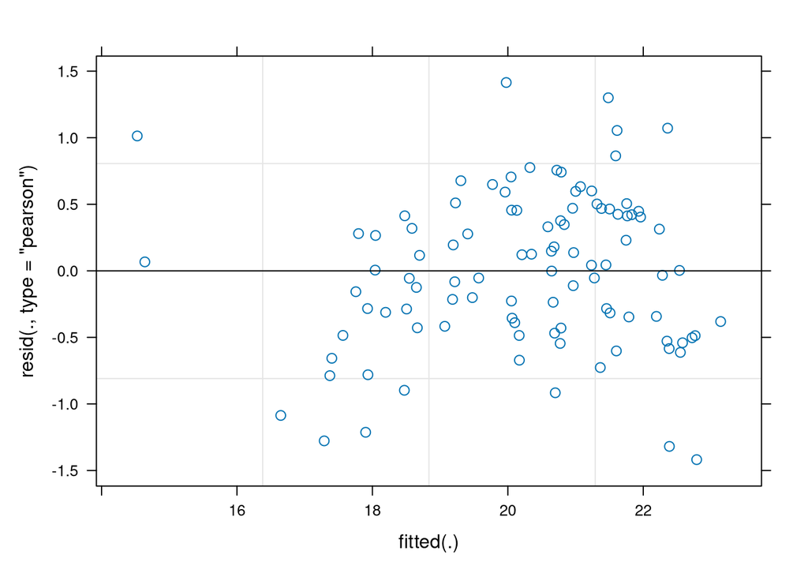

```r
plot(mod)
```

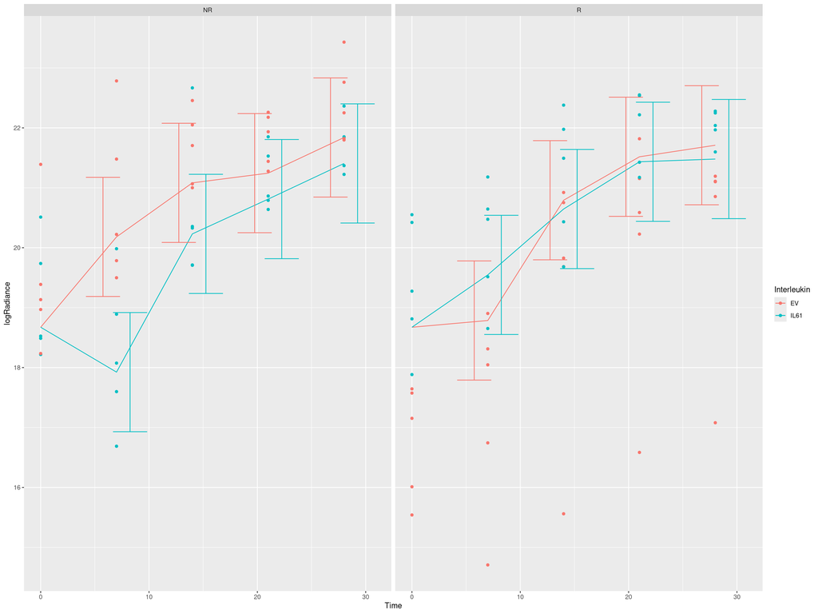

```r
emm_res <- broom::tidy(emm) %>% rename(Interleukin = InteractionIL, Radiation = InteractionR)
emm_res <- rbind(emm_res[1,], emm_res)
emm_res <- rbind(emm_res[1,], emm_res)
emm_res <- rbind(emm_res[1,], emm_res)
emm_res[1:4, 1] <- rep(c("EV", "IL61"), 2)
emm_res[1:4, 2] <- rep(c("NR", "R"), each = 2)
dat %>%
  ggplot(aes(x = Time, y = logRadiance, color=Interleukin)) +
    geom_point() +
    geom_line(aes(x = as.numeric(facTime), y=estimate), data = emm_res) +
    geom_errorbar(aes(x = as.numeric(facTime), y=estimate, ymin = estimate - 2*std.error, ymax=estimate + 2*std.error), data=emm_res %>% filter(facTime != 0), position=position_dodge(5)) +
    facet_wrap( ~ Radiation )
```

The only statistically significant (even at $\alpha = 0.1$) effect is the difference between EV and IL61 at 7 days when non-irradiated. Between 0 and 7 days, IL61 tumor burden shrunk. After this, they grew back fast enough to rejoin the EV group, and a statistically significant change was not detected.

IL61 seems to have no effect on the radiated group.

```r
DT::datatable(emm_res, options=list(scrollX=T))
```

|  | Interleukin | Radiation | facTime | estimate | std.error | df | statistic | p.value |
| --- | --- | --- | --- | --- | --- | --- | --- | --- |
| 1 | EV | NR | 0 | 18.67317698900291 | 0.3292957052284912 | 26.97883250096234 | 56.70640914082375 | 1.34235132037596e-29 |
| 2 | IL61 | NR | 0 | 18.67317698900291 | 0.3292957052284912 | 26.97883250096234 | 56.70640914082375 | 1.34235132037596e-29 |
| 3 | EV | R | 0 | 18.67317698900291 | 0.3292957052284912 | 26.97883250096234 | 56.70640914082375 | 1.34235132037596e-29 |
| 4 | IL61 | R | 0 | 18.67317698900291 | 0.3292957052284912 | 26.97883250096234 | 56.70640914082375 | 1.34235132037596e-29 |
| 5 | EV | NR | 7 | 20.18048313953846 | 0.4971631413678329 | 67.1006601517166 | 40.59126966656537 | 5.944804642762721e-49 |
| 6 | IL61 | NR | 7 | 17.92377838437302 | 0.4971631413678329 | 67.1006601517166 | 36.05210622625757 | 1.203175235362741e-45 |
| 7 | EV | R | 7 | 18.78554953572754 | 0.4971631413678325 | 67.10066015171601 | 37.7854832199413 | 5.959227014265506e-47 |
| 8 | IL61 | R | 7 | 19.54671414196439 | 0.4971631413678332 | 67.1006601517166 | 39.31649898298168 | 4.645393968224207e-48 |
| 9 | EV | NR | 14 | 21.08273550336105 | 0.4971631413678329 | 67.1006601517169 | 42.40607106423181 | 3.521099641391237e-50 |
| 10 | IL61 | NR | 14 | 20.23118357587501 | 0.497163141367833 | 67.1006601517166 | 40.69324914194854 | 5.056256475090303e-49 |

[output cut: 10 more lines]

```r
contrast_results <- emmeans::contrast(emm, method="pairwise", adjust="tukey")
DT::datatable(as.data.frame(contrast_results) %>%
  mutate(fc = exp(abs(estimate))),
  options = list(scrollX=T)
  )
```

|  | facTime | InteractionR | contrast | estimate | SE | df | t.ratio | p.value | fc |
| --- | --- | --- | --- | --- | --- | --- | --- | --- | --- |
| 1 | 0 | NoInteraction | (nothing) |  |  |  |  |  |  |
| 2 | 7 | NR | EV - IL61 | 2.256704755165443 | 0.6082445290129128 | 77.04716596922589 | 3.71019326524437 | 0.0003889961521916785 | 9.551562514235986 |
| 3 | 7 | R | EV - IL61 | -0.7611646062368579 | 0.6082445290129129 | 77.0471659692255 | -1.251412170483655 | 0.2145704244645271 | 2.140767920962659 |
| 4 | 14 | NR | EV - IL61 | 0.8515519274860328 | 0.6082445290129128 | 77.04716596922628 | 1.400015761535859 | 0.1655225364028997 | 2.343280633136251 |
| 5 | 14 | R | EV - IL61 | 0.1468975100990139 | 0.6082445290129127 | 77.0471659692255 | 0.2415106147151146 | 0.8098009942806403 | 1.158235249530449 |
| 6 | 21 | NR | EV - IL61 | 0.4331844270420068 | 0.6082445290129127 | 77.04716596922589 | 0.7121879546454755 | 0.4784995018890805 | 1.542160610594944 |
| 7 | 21 | R | EV - IL61 | 0.08322070749033829 | 0.608244529012913 | 77.0471659692255 | 0.1368211361068757 | 0.8915290718344866 | 1.086781642929599 |
| 8 | 28 | NR | EV - IL61 | 0.4330837885276496 | 0.6082445290129127 | 77.04716596922628 | 0.7120224973177778 | 0.4786013702172636 | 1.542005417651519 |
| 9 | 28 | R | EV - IL61 | 0.2309313170912418 | 0.6082445290129129 | 77.04716596922589 | 0.3796685478881457 | 0.7052359648159408 | 1.259772711623566 |

# ################NO NEED TO READ PAST HERE

# Mean % increase over time per group

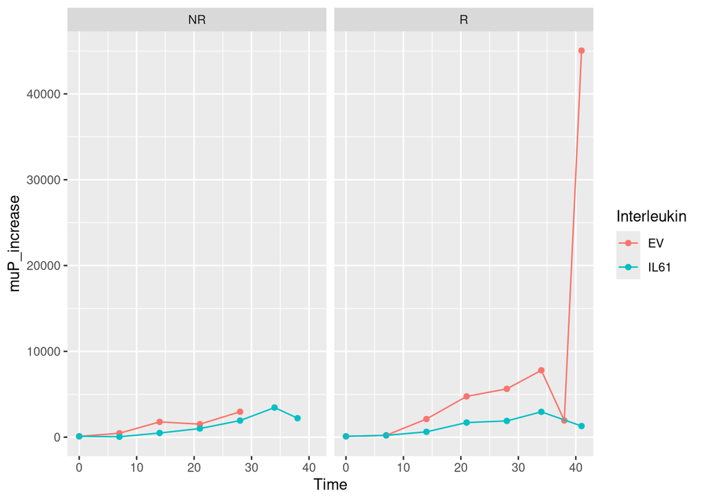

```r
dat_full %>%
  group_by(Mouse) %>%
  mutate(p_increase = 100 * (Radiance / Radiance[1])) %>%
  group_by(Interleukin, Radiation, Time) %>%
  summarize(muP_increase = mean(p_increase)) %>%
  ggplot(aes(x = Time, y = muP_increase, color = Interleukin)) +
    geom_point() +
    geom_line() +
    facet_wrap( ~ Radiation )
```

# Mean *log*-% increase over time per group

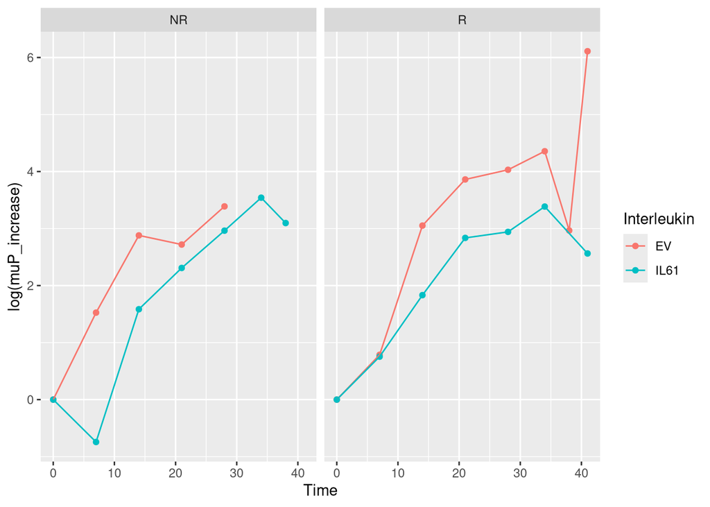

```r
dat_full %>%
  group_by(Mouse) %>%
  mutate(p_increase = (Radiance / Radiance[1])) %>%
  group_by(Interleukin, Radiation, Time) %>%
  summarize(muP_increase = mean(p_increase)) %>%
  ggplot(aes(x = Time, y = log(muP_increase ), color = Interleukin)) +
    geom_point() +
    geom_line() +
    facet_wrap( ~ Radiation )
```